# Figures for Bacterial Community Dynamics in an Oyster Hatchery in Response to Probiotic Treatment

Rebecca Stevick, contact: rstevick@uri.edu

Finalized March 12, 2019

```r
#load libraries
library(ggplot2)
library(gridExtra)
library(dplyr)
library(tidyr)
library(ggpubr)
library(openxlsx)
library(vegan)
library(phyloseq)
library(Scale)
```

# Figure 1. Percent Abundances

This figure uses the abundance data by Phyla to plot the number of reads per sample and the percent abundance of phyla per sample. First, we’ll import the data and metadata.

```r
abund_table<-read.xlsx("OysterHatcheryMicrobiome_phyladata.xlsx",sheet="taxa", rowNames = TRUE)
meta_table<-read.xlsx("OysterHatcheryMicrobiome_phyladata.xlsx",sheet="meta")
```

Next we’ll edit the data and merge the taxa data with the metadata so it’s ready to plot.

```r
# order the abundance table by decreasing abundances
abund_table<-abund_table[,order(colSums(abund_table),decreasing=TRUE)]

#Extract list of top 12 Taxa and call everything else "Unknown"
N<-12 # can change number of taxa to plot here
taxa_list<-colnames(abund_table)[1:N]
#Generate a new table with everything added to Others
new_abund<-data.frame(abund_table[,colnames(abund_table) %in% taxa_list],
          Others=rowSums(abund_table[,!colnames(abund_table) %in% taxa_list]))
#convert the taxa data into long format
#name the column with the phylum name "Taxa" and the column with the percent abundance values "Value"
new_abund_long<-gather(new_abund, Taxa, Value)
#Define leves of the taxa so that it plots in the correct order
new_abund_long$Taxa<-factor(new_abund_long$Taxa, levels = unique(new_abund_long$Taxa))

#Make a new data fram called meta_taxa and merge the metadata and long taxa data
meta_taxa<-as.data.frame(c(meta_table, new_abund_long))
```

Now we’ll plot the percent abundances and the number of reads per sample.

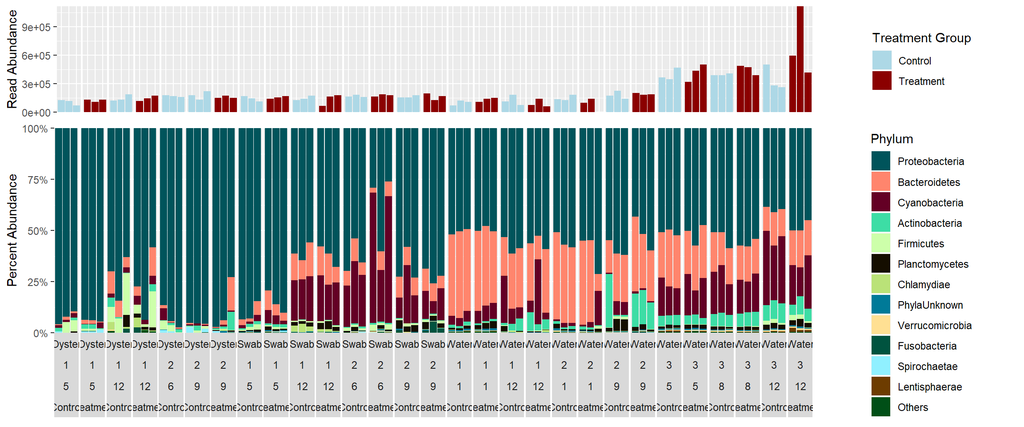

```r
# define the palette we'll use for the percent abundances
palette<-c("#00545b","#ff856d","#640025","#3ddda5","#cdffaa","#150e00","#bae278",
             "#007a98","#ffe093","#00533f","#90f0ff","#6d3c00","#004f17")

# plot the number of reads per sample
pc<-ggplot(meta_table,aes(Samples,ReadCount, fill=Group))+
  # plot using columns
  geom_col()+
  # facet by type, then trial, then day, then treatment group.
  facet_grid(.~Type+Trial+Day+Group,drop=TRUE, scale="free_x")+
  # label the axes
  labs(y="Read Abundance", x=NULL)+
  # change the fill color to Control= light blue, Treatment=dark red.
  scale_fill_manual(values=c("light blue", "dark red"))+
  scale_y_continuous(expand = c(0,0))+
  # edit the facets a little
  theme(strip.text = element_blank(),legend.position="none",
        axis.ticks.x = element_blank(),
        panel.spacing = unit(0.1,"lines"),axis.text.x = element_blank())

# plot the percent abundances
p<-ggplot(meta_taxa,aes(Samples,Value,fill=Taxa))+geom_col(position="stack")+
  facet_grid(.~Type+Trial+Day+Group, drop=TRUE,scale="free", space="free",switch="x")+
  scale_fill_manual(values=palette)+labs(x=NULL, y="Percent Abundance")+
  scale_y_continuous(expand = c(0,0),labels=scales::percent)+
  theme(strip.background = element_rect(fill="gray85"),legend.position="none",
        panel.spacing = unit(0.1,"lines"), axis.text.x = element_blank(),
        axis.ticks.x = element_blank())

# get the legend for each plot
g_legend<-function(a.gplot){
  tmp <- ggplot_gtable(ggplot_build(a.gplot))
  leg <- which(sapply(tmp$grobs, function(x) x$name) == "guide-box")
  legend <- tmp$grobs[[leg]]
  return(legend)}
legendp<-g_legend(ggplot(meta_taxa,aes(Samples,Value,fill=Taxa))+
                    geom_col()+scale_fill_manual(values=palette)+labs(fill="Phylum"))
legendpc<-g_legend(ggplot(meta_table,aes(Samples,ReadCount, fill=Group))+
                     geom_col()+scale_fill_manual(values=c("light blue", "dark red"))+labs(fill="Treatment Group"))

# plot the figures and legends together
grid.arrange(pc, legendpc, p, legendp, nrow=2, ncol=2, heights=c(1,2.5), widths=c(4,1))
```